# Project 1

Aspen Saplan

2026-02-23

# Set up of dataset walmart:

```r
#getwd()
walmart = read.csv("Walmart.csv")
walmart$category = as.factor(walmart$category)
walmart$store_location = as.factor(walmart$store_location)
walmart$customer_loyalty_level = as.factor(walmart$customer_loyalty_level)
walmart$payment_method = as.factor(walmart$payment_method)
print(str(walmart))
```

```
## 'data.frame':    5000 obs. of  28 variables:
##  $ transaction_id        : int  1 2 3 4 5 6 7 8 9 10 ...
##  $ customer_id           : int  2824 1409 5506 5012 4657 3286 2679 9935 2424 7912 ...
##  $ product_id            : int  843 135 391 710 116 630 238 409 106 407 ...
##  $ product_name          : chr  "Fridge" "TV" "Fridge" "Smartphone" ...
##  $ category              : Factor w/ 2 levels "Appliances","Electronics": 2 2 2 2 2 2 1 2 2 1 ...
##  $ quantity_sold         : int  3 4 4 5 3 4 3 4 4 5 ...
##  $ unit_price            : num  188 1912 1378 182 499 ...
##  $ transaction_date      : chr  "3/31/2024 21:46" "7/28/2024 12:45" "6/10/2024 4:55" "8/15/2024 1:03" ...
##  $ store_id              : int  3 5 1 5 6 1 3 16 12 10 ...
##  $ store_location        : Factor w/ 5 levels "Chicago, IL",..: 4 2 3 4 1 5 2 3 5 1 ...
##  $ inventory_level       : int  246 43 411 452 412 196 24 125 103 424 ...
##  $ reorder_point         : int  116 70 94 87 99 80 52 92 129 88 ...
##  $ reorder_quantity      : int  170 212 252 112 177 210 287 178 172 253 ...
##  $ supplier_id           : int  474 135 475 118 155 169 250 248 368 494 ...
##  $ supplier_lead_time    : int  8 4 2 7 4 4 3 5 4 1 ...
##  $ customer_age          : int  29 34 69 47 70 40 54 57 64 24 ...
##  $ customer_gender       : chr  "Other" "Other" "Other" "Other" ...
##  $ customer_income       : num  98761 69782 77373 33383 108999 ...
##  $ customer_loyalty_level: Factor w/ 4 levels "Bronze","Gold",..: 4 2 3 4 1 1 3 4 3 1 ...
##  $ payment_method        : Factor w/ 4 levels "Cash","Credit Card",..: 2 1 1 1 4 2 1 3 2 4 ...
##  $ promotion_applied     : logi  TRUE TRUE FALSE TRUE FALSE TRUE ...
##  $ promotion_type        : chr  "None" "Percentage Discount" "None" "Percentage Discount" ...
##  $ weather_conditions    : chr  "Stormy" "Rainy" "Sunny" "Sunny" ...
##  $ holiday_indicator     : logi  FALSE FALSE FALSE TRUE FALSE TRUE ...
##  $ weekday               : chr  "Friday" "Monday" "Tuesday" "Sunday" ...
##  $ stockout_indicator    : logi  TRUE TRUE TRUE FALSE TRUE FALSE ...
##  $ forecasted_demand     : int  172 109 289 174 287 294 178 165 476 395 ...
##  $ actual_demand         : int  179 484 416 446 469 265 257 264 428 400 ...
## NULL
```

# Summaries of variables:

### The summary of category:

```r
summary(walmart$category)
```

```
##  Appliances Electronics
##        2415        2585
```

### The summary of store_location:

```r
summary(walmart$store_location)
```

```
##     Chicago, IL      Dallas, TX Los Angeles, CA       Miami, FL    New York, NY
##            1013             998            1038             964             987
```

### The summary of customer_income:

```r
summary(walmart$customer_income)
```

```
##    Min. 1st Qu.  Median    Mean 3rd Qu.    Max.
##   20005   44865   70188   70042   95396  120000
```

### The summary of customer_loyalty_level:

```r
summary(walmart$customer_loyalty_level)
```

```
##   Bronze     Gold Platinum   Silver
##     1253     1160     1299     1288
```

### The summary of payment_method:

```r
summary(walmart$payment_method)
```

```
##           Cash    Credit Card     Debit Card Digital Wallet
##           1246           1281           1210           1263
```

# Checking if NA values exist:

### Category

Sum of category NA values: 0

### store_location

Sum of store_location NA values: 0

### customer_income

Sum of customer_income NA values: 0

### customer_loyalty_level

Sum of customer_loyalty_level NA values: 0

### payment_method

Sum of payment_method NA values: 0

# EDA of category and store_location:

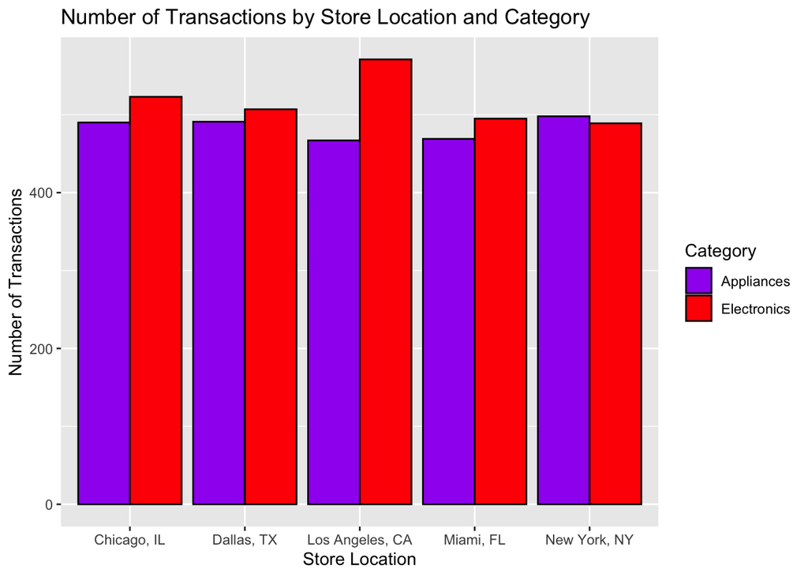

```r
library(ggplot2)
ggplot(walmart, aes(x = store_location, fill = category)) +
  geom_bar(position = "dodge", color = "black")+
  scale_fill_manual(values = c(
    "Appliances" = "purple",
    "Electronics" = "red"
  ))+
  labs(title = "Number of Transactions by Store Location and Category",
    x = "Store Location",
    y = "Number of Transactions",
    fill = "Category")
```

# EDA of category and customer_income:

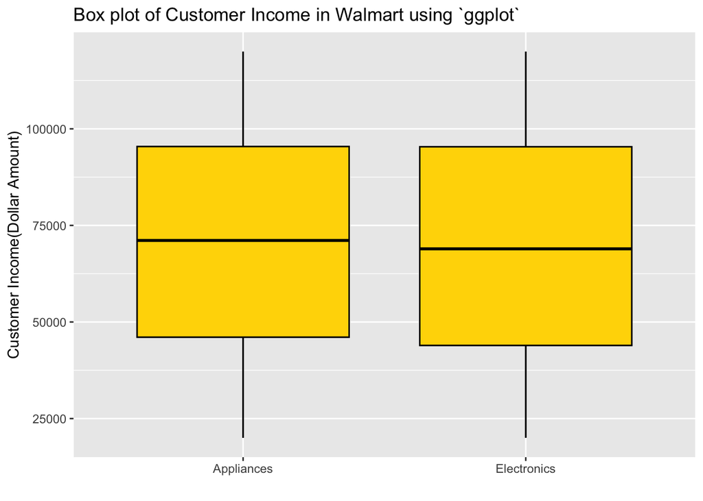

```r
ggplot(walmart, aes(x = category, y=customer_income)) +
  geom_boxplot() +
  geom_boxplot( color="black", fill="gold", outlier.colour="blue", outlier.shape=19, outlier.size=2) +
  labs(title="Box plot of Customer Income in Walmart using `ggplot`", x="", y = "Customer Income(Dollar Amount)")
```

The data looks pretty similar across both appliances and electronics.

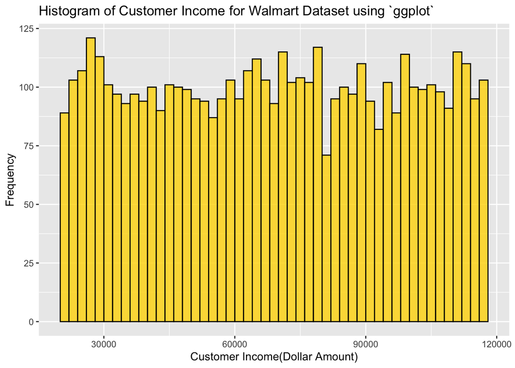

```r
library(ggplot2)
ggplot(data=walmart, aes(customer_income)) +
  geom_histogram(breaks=seq(20005.34, 119999.8, by = 2000),
                 col="black",
                 fill="gold",
                 alpha = .8) + # opacity
  labs(x="Customer Income(Dollar Amount)", y="Frequency") +
  labs(title="Histogram of Customer Income for Walmart Dataset using `ggplot`")
```

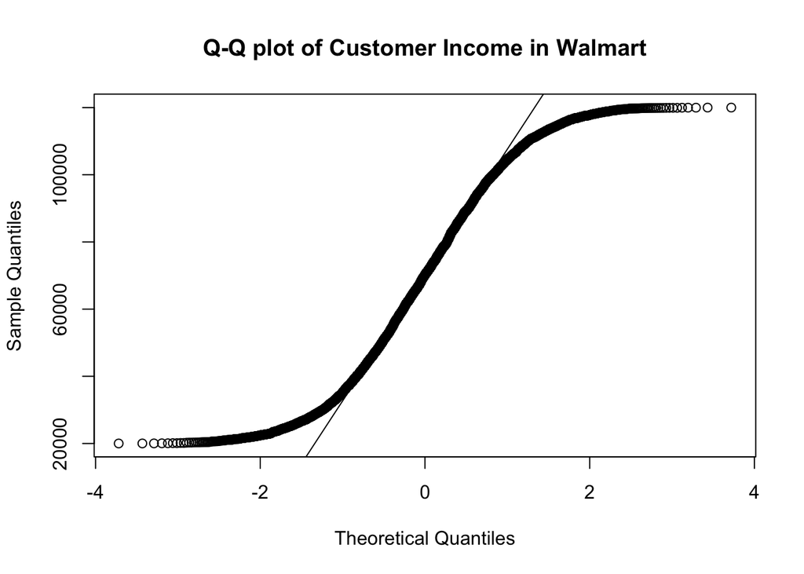

```r
qqnorm(walmart$customer_income, main="Q-Q plot of Customer Income in Walmart")
qqline(walmart$customer_income)
```

The distribution for the customer_income as a whole is approximately uniform with no strong skewing.

## Subset of appliances:

```r
appliances = subset(walmart, category == "Appliances")
print(head(appliances[, c("category", "customer_income")], n=5))
```

```
##      category customer_income
## 7  Appliances        75813.17
## 10 Appliances        44787.70
## 12 Appliances        52253.32
## 13 Appliances        22027.62
## 14 Appliances        65337.53
```

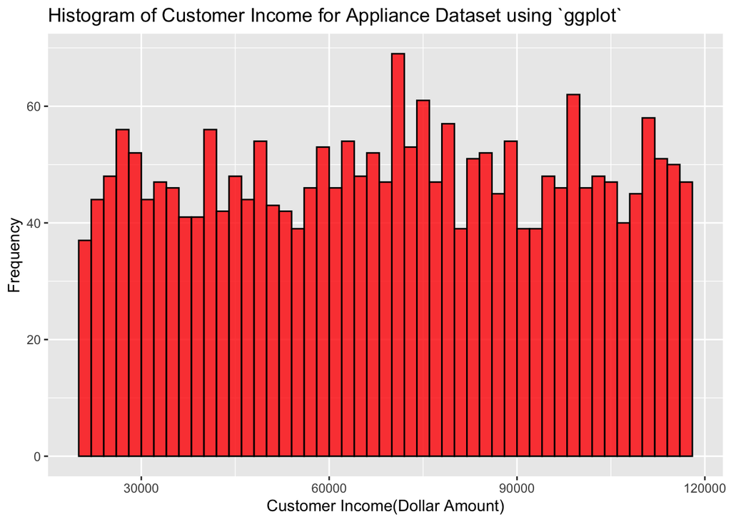

```r
library(ggplot2)
ggplot(data=appliances, aes(customer_income)) +
  geom_histogram(breaks=seq(20005.34, 119999.8, by = 2000),
                 col="black",
                 fill="red",
                 alpha = .8) + # opacity
  labs(x="Customer Income(Dollar Amount)", y="Frequency") +
  labs(title="Histogram of Customer Income for Appliance Dataset using `ggplot`")
```

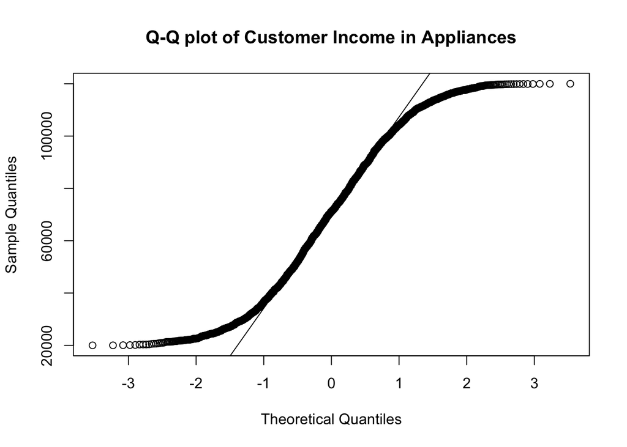

```r
qqnorm(appliances$customer_income, main="Q-Q plot of Customer Income in Appliances")
qqline(appliances$customer_income)
```

The distribution for the customer_income for appliances is approximately uniform with no strong skewing.

## Subset of electronics:

```r
electronics = subset(walmart, category == "Electronics")
print(head(electronics[, c("category", "customer_income")], n=5))
```

```
##      category customer_income
## 1 Electronics        98760.83
## 2 Electronics        69781.93
## 3 Electronics        77373.10
## 4 Electronics        33383.04
## 5 Electronics       108999.41
```

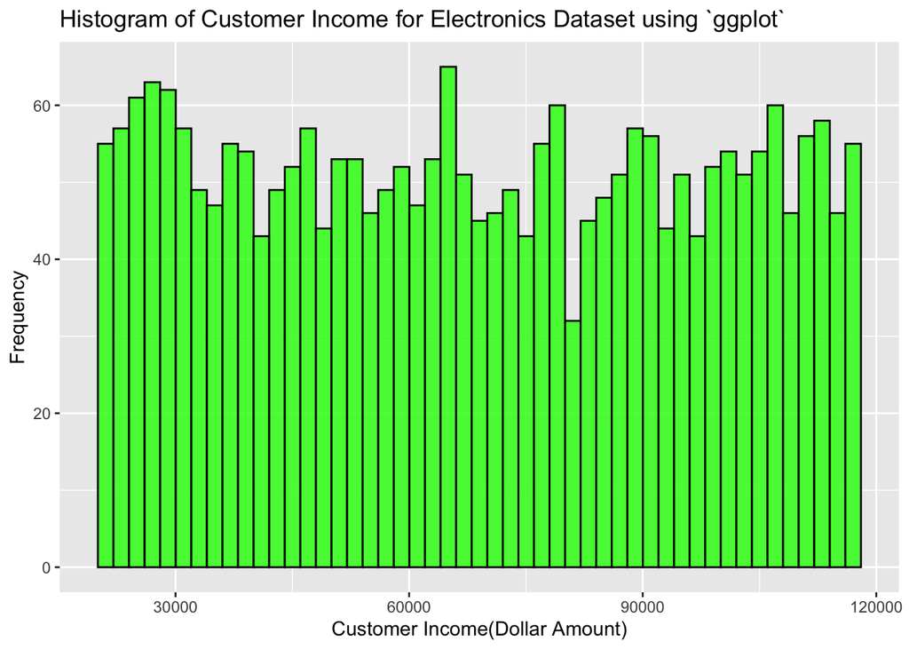

```r
library(ggplot2)
ggplot(data=electronics, aes(customer_income)) +
  geom_histogram(breaks=seq(20028.81, 119997.5, by = 2000),
                 col="black",
                 fill="green",
                 alpha = .8) + # opacity
  labs(x="Customer Income(Dollar Amount)", y="Frequency") +
  labs(title="Histogram of Customer Income for Electronics Dataset using `ggplot`")
```

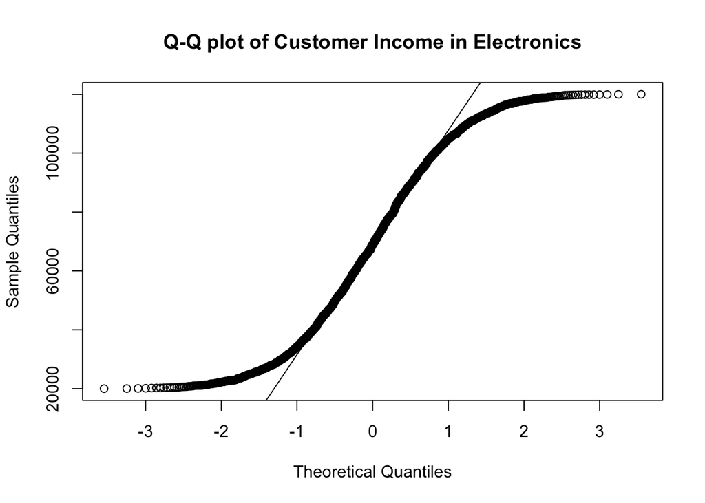

```r
qqnorm(electronics$customer_income, main="Q-Q plot of Customer Income in Electronics")
qqline(electronics$customer_income)
```

The distribution for the customer_income for electronics is approximately uniform with no strong skewing.

# EDA of category and customer_loyalty_level:

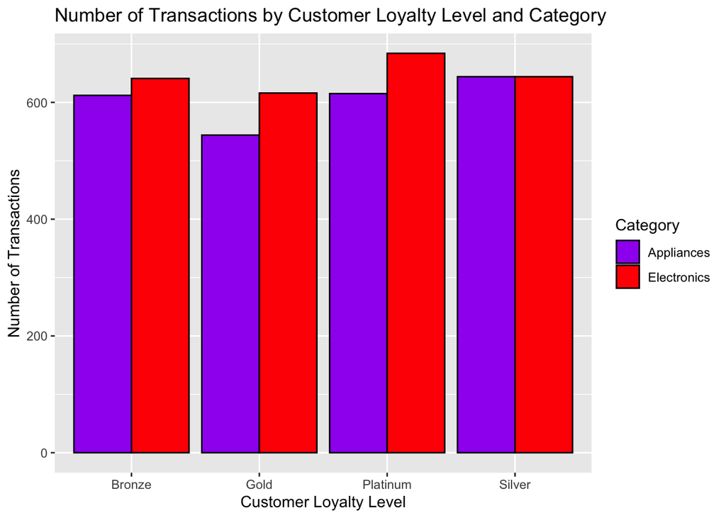

```r
library(ggplot2)
ggplot(walmart, aes(x = customer_loyalty_level, fill = category)) +
  geom_bar(position = "dodge", color = "black")+
  scale_fill_manual(values = c(
    "Appliances" = "purple",
    "Electronics" = "red"
  ))+
  labs(title = "Number of Transactions by Customer Loyalty Level and Category",
    x = "Customer Loyalty Level",
    y = "Number of Transactions",
    fill = "Category")
```

# EDA of category and payment_method:

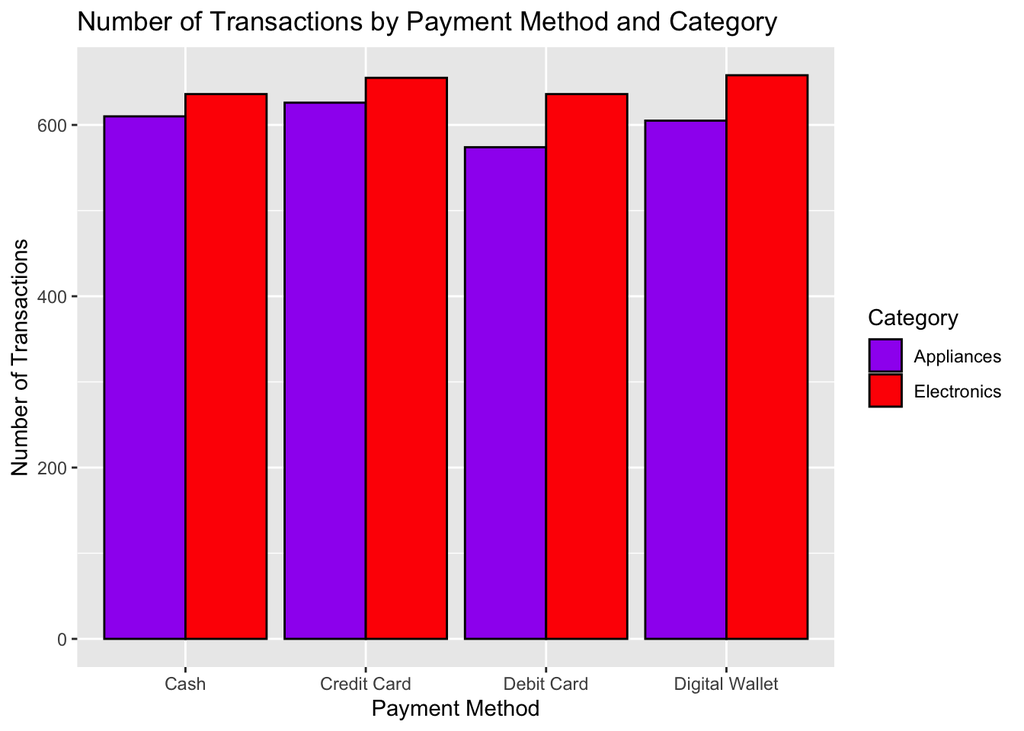

```r
library(ggplot2)
ggplot(walmart, aes(x = payment_method, fill = category)) +
  geom_bar(position = "dodge", color = "black")+
  scale_fill_manual(values = c(
    "Appliances" = "purple",
    "Electronics" = "red"
  ))+
  labs(title = "Number of Transactions by Payment Method and Category",
    x = "Payment Method",
    y = "Number of Transactions",
    fill = "Category")
```

# Chi Square Test of store_location and category

```r
contableSL = table(walmart$category, walmart$store_location)
xkabledply(contableSL, title="Contingency table for category and store_location within walmart dataset")
```

Contingency table for category and store_location within walmart dataset

|  | Chicago, IL | Dallas, TX | Los Angeles, CA | Miami, FL | New York, NY |
| --- | --- | --- | --- | --- | --- |
| Appliances | 490 | 491 | 467 | 469 | 498 |
| Electronics | 523 | 507 | 571 | 495 | 489 |

## Test of Independence on category and store_location on contable

Null Hypothesis: Category and store_location are independent

Alternative Hypothesis: Category and store_location are not independent

Alpha = 0.05

```r
chitestSL = chisq.test(contableSL)
chitestSL
```

```
##
##  Pearson's Chi-squared test
##
## data:  contableSL
## X-squared = 6.7627, df = 4, p-value = 0.149
```

Conclusion: Since the p-value(0.1489722) is greater than the alpha(0.05) we can conclude that we cannot reject the null hypothesis. Which provides evidence suggesting that store_location and category are independent.

# T-Test of customer_income and category

Customer_income Null Hypothesis: means are equal for appliances and electronics

Customer_income Alternative Hypothesis: means are not equal for appliances and electronics

Alpha = 0.05

```r
ttestCI = t.test(appliances$customer_income, electronics$customer_income)
ttestCI
```

```
##
##  Welch Two Sample t-test
##
## data:  appliances$customer_income and electronics$customer_income
## t = 1.3643, df = 4990.2, p-value = 0.1725
## alternative hypothesis: true difference in means is not equal to 0
## 95 percent confidence interval:
##  -489.6096 2730.8529
## sample estimates:
## mean of x mean of y
##  70620.99  69500.37
```

# Chi Square Test of customer_loyalty_level and category

```r
contableCLL = table(walmart$category, walmart$customer_loyalty_level)
xkabledply(contableCLL, title="Contingency table for category and customer_loyalty_level within walmart dataset")
```

Contingency table for category and customer_loyalty_level within walmart dataset

|  | Bronze | Gold | Platinum | Silver |
| --- | --- | --- | --- | --- |
| Appliances | 612 | 544 | 615 | 644 |
| Electronics | 641 | 616 | 684 | 644 |

## Test of Independence on category and customer_loyalty_level on contable

Null Hypothesis: Category and customer_loyalty_level are independent

Alternative Hypothesis: Category and customer_loyalty_level are not independent

Alpha = 0.05

```r
chitestCLL = chisq.test(contableCLL)
chitestCLL
```

```
##
##  Pearson's Chi-squared test
##
## data:  contableCLL
## X-squared = 3.0288, df = 3, p-value = 0.3872
```

Conclusion: Since the p-value(0.3872087) is greater than the alpha(0.05) we can conclude that we cannot reject the null hypothesis. Which provides evidence suggesting that customer_loyalty_level and category are independent.

# Chi Square Test of payment_method and category

```r
contablePM = table(walmart$category, walmart$payment_method)
xkabledply(contablePM, title="Contingency table for category and payment_method within walmart dataset")
```

Contingency table for category and payment_method within walmart dataset

|  | Cash | Credit Card | Debit Card | Digital Wallet |
| --- | --- | --- | --- | --- |
| Appliances | 610 | 626 | 574 | 605 |
| Electronics | 636 | 655 | 636 | 658 |

## Test of Independence on category and payment_method on contable

Null Hypothesis: Category and payment_method are independent

Alternative Hypothesis: Category and payment_method are not independent

Alpha = 0.05

```r
chitestPM = chisq.test(contablePM)
chitestPM
```

```
##
##  Pearson's Chi-squared test
##
## data:  contablePM
## X-squared = 0.82093, df = 3, p-value = 0.8445
```

Conclusion: Since the p-value(0.8444539) is greater than the alpha(0.05) we can conclude that we cannot reject the null hypothesis. Which provides evidence suggesting that payment_method and category are independent.